# Лабораторная работа №8

Diagrams and drawings as code (TikZ)

Оффеи Эндрю

Российский университет дружбы народов, Москва, Россия

Марта 2026

# Цель работы

# Основная цель

Изучение возможностей пакета **TikZ** для создания графических объектов в LaTeX, включая построение графов, графиков функций и фрактальных структур, а также освоение принципов описания изображений в виде кода.

# Exercise 8.2.1 — Graph

# Компиляция исходного файла

Файл `exercise8_1.tex` был открыт в текстовом редакторе и скомпилирован с помощью команды `pdflatex`.

Использовались: - TeX Live 2025  
- класс документа `article`  
- пакет `tikz`

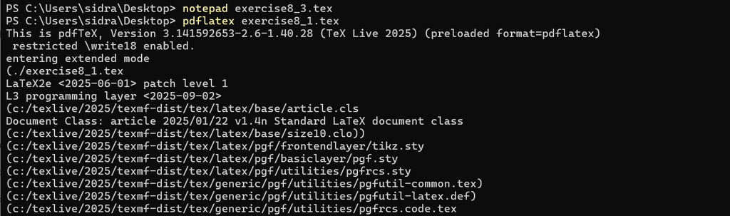

Компиляция exercise8_1.tex

# Полученный результат

В результате компиляции был сформирован PDF-документ, содержащий граф с узлами и взвешенными рёбрами.

Особенности графа: - узлы оформлены в виде окружностей; - рёбра соединяют внешние и внутренние вершины; - веса рёбер подписаны непосредственно на линиях.

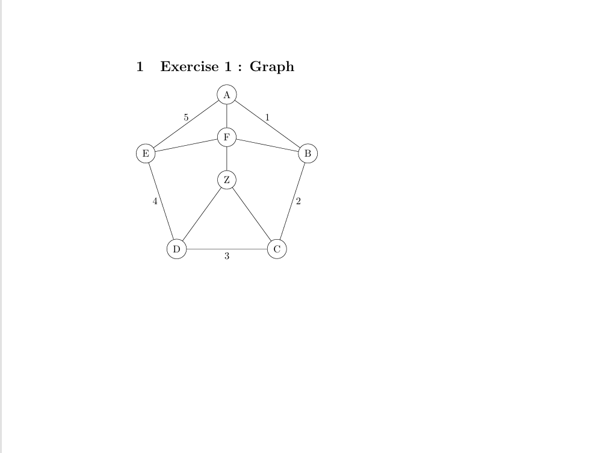

Результат Exercise 8.2.1

# Exercise 8.2.2 — Plot

# Компиляция исходного файла

Файл `exercise8_2.tex` был скомпилирован с использованием `pdflatex`.

Использовались: - TeX Live 2025  
- пакет `tikz` - стандартные средства TikZ для построения графиков

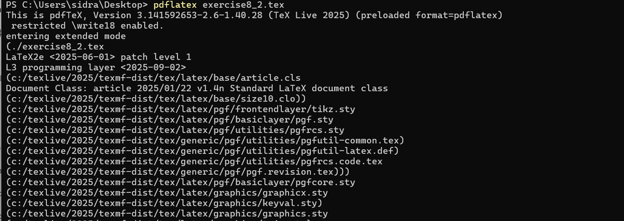

Компиляция exercise8_2.tex

# Построение графиков функций

В итоговом PDF-документе представлены:

- оси координат с подписями;
- график функции y = e^x;
- график функции y = ln(x);
- вспомогательные линии x = 1 и y = 1.

Каждый элемент выделен цветом и снабжён текстовой подписью.

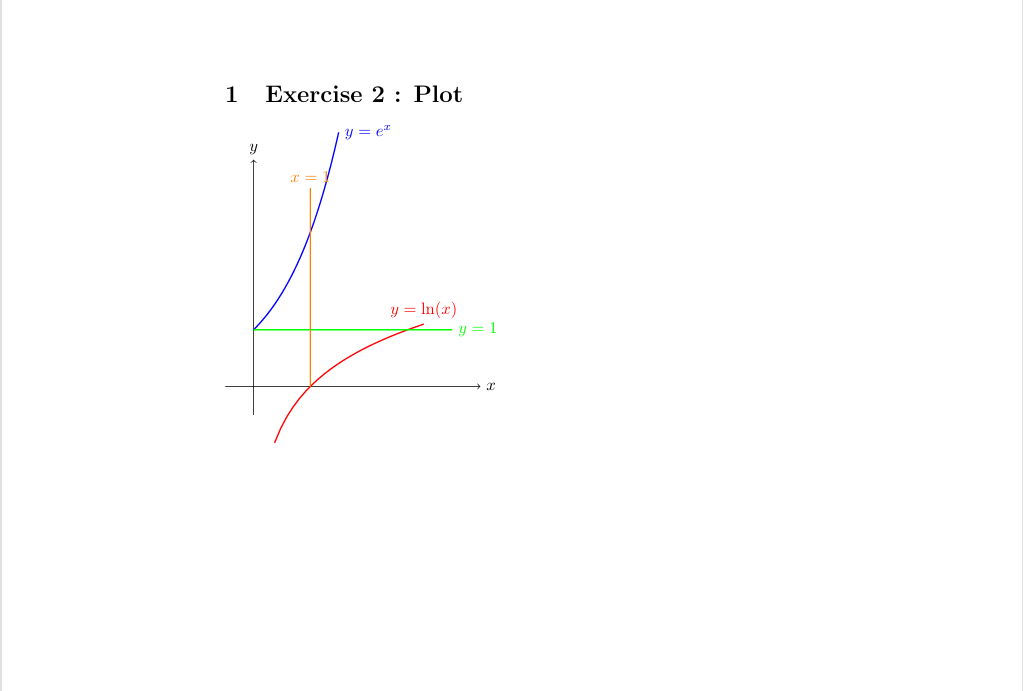

Результат Exercise 8.2.2

# Exercise 8.2.3 — Sierpinski Carpet

# Компиляция исходного файла

Файл `exercise8_3.tex` был открыт и скомпилирован командой `pdflatex`.

Использовались: - TeX Live 2025  
- пакет `tikz` - механизмы итераций и геометрических построений

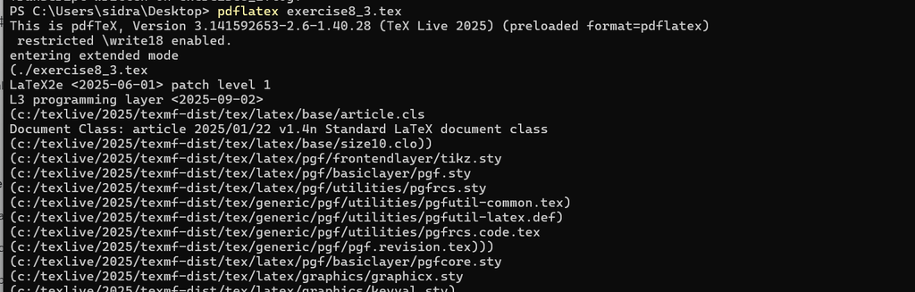

Компиляция exercise8_3.tex

# Фрактальная структура

В результате был построен фрактал **ковёр Серпинского**, полученный путём итеративного удаления центральных квадратов.

Особенности реализации: - повторяющиеся геометрические элементы; - строгая симметрия; - масштабирование базовой фигуры.

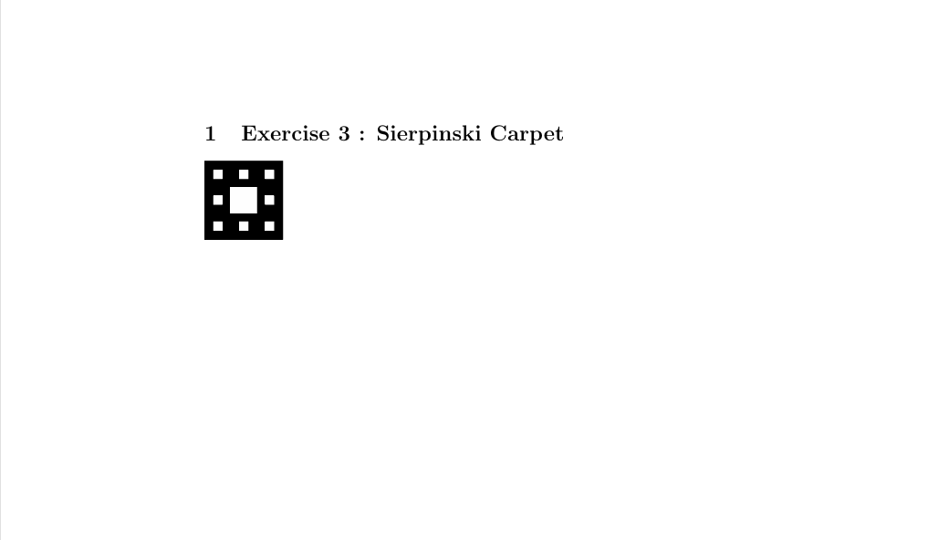

Результат Exercise 8.2.3

# Итоги работы

# Вывод

В ходе лабораторной работы были освоены:

- основы работы с пакетом `tikz`;
- построение графов с узлами и рёбрами;
- визуализация математических функций;
- добавление осей, подписей и вспомогательных элементов;
- создание сложных итеративных структур на примере фракталов.

Пакет **TikZ** позволяет эффективно создавать качественные и воспроизводимые графические объекты непосредственно в LaTeX-документах.